# BREZZA PLATANIA SALVATORE

# •Valentina • Salvatore • Paola • Fabrizzio

## Stagisti Corso Addetto alla logistica automatica ambito IOT FORIT GROUP , POLITECNICO RIZZO , FOMATEMP AGENZIA GI GROUP Lavoro di gruppo alcuni esempi macchine learing Esercitazione Intelligenza artificiale PYTHON

```
Intercetta (b0): 1.7999999999999998
Coefficiente (b1): 0.7714285714285715
```

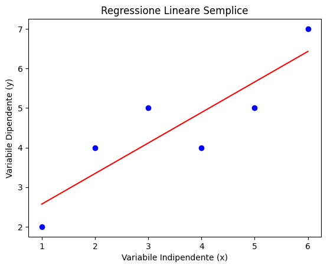

```python
# Importiamo le librerie necessarie
import numpy as np
import matplotlib.pyplot as plt
from sklearn.linear_model import LinearRegression

# Generiamo dei dati sintetici
# Variabile indipendente (x)
x = np.array([1, 2, 3, 4, 5, 6]).reshape((-1, 1))
# Variabile dipendente (y)
y = np.array([2, 4, 5, 4, 5, 7])

# Creiamo il modello di regressione lineare
model = LinearRegression()

# Addestriamo il modello
model.fit(x, y)

# Facciamo una previsione
y_pred = model.predict(x)

# Mostriamo i risultati
print(f"Intercetta (b0): {model.intercept_}")
print(f"Coefficiente (b1): {model.coef_[0]}")

# Visualizziamo i dati e la retta di regressione
plt.scatter(x, y, color='blue')  # Dati originali
plt.plot(x, y_pred, color='red')  # Retta di regressione
plt.title('Regressione Lineare Semplice')
plt.xlabel('Variabile Indipendente (x)')
plt.ylabel('Variabile Dipendente (y)')
plt.show()
```

# Spiegazione:

Dati: La quantità rappresenta la produzione di farmaci in migliaia di unità. Il prezzo è il costo per unità di farmaco in euro. Man mano che la quantità prodotta aumenta, il prezzo per unità tende a diminuire (economia di scala). Modello di regressione: Addestriamo un modello per capire come la quantità prodotta influenza il prezzo del farmaco. Il modello stima la relazione lineare tra la quantità e il prezzo, con un'intercetta e un coefficiente angolare. Output: Intercetta e coefficiente: L'intercetta indica il prezzo stimato quando la quantità prodotta è zero. Il coefficiente angolare mostra di quanto cambia il prezzo per ogni aumento di 1.000 unità prodotte. Grafico: I punti blu rappresentano i dati reali (quantità e prezzo). La linea rossa rappresenta la previsione del modello di regressione, cioè come il prezzo dovrebbe variare con la quantità prodotta.

```
Intercetta (b0): 19.8
Coefficiente (b1): -0.8727272727272729
```

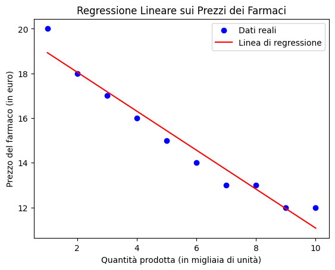

```python
# Importiamo le librerie necessarie
import numpy as np
import matplotlib.pyplot as plt
from sklearn.linear_model import LinearRegression

# Dataset fittizio (quantità prodotta e prezzo)
# Quantità di farmaci prodotti (in migliaia di unità)
quantita = np.array([1, 2, 3, 4, 5, 6, 7, 8, 9, 10]).reshape((-1, 1))

# Prezzi del farmaco (in euro)
prezzi = np.array([20, 18, 17, 16, 15, 14, 13, 13, 12, 12])

# Creiamo il modello di regressione lineare
model = LinearRegression()

# Addestriamo il modello
model.fit(quantita, prezzi)

# Facciamo una previsione
prezzi_predetti = model.predict(quantita)

# Mostriamo i risultati
print(f"Intercetta (b0): {model.intercept_}")
print(f"Coefficiente (b1): {model.coef_[0]}")

# Visualizziamo i dati reali e la linea di regressione
plt.scatter(quantita, prezzi, color='blue', label='Dati reali')
plt.plot(quantita, prezzi_predetti, color='red', label='Linea di regressione')
plt.title('Regressione Lineare sui Prezzi dei Farmaci')
plt.xlabel('Quantità prodotta (in migliaia di unità)')
plt.ylabel('Prezzo del farmaco (in euro)')
plt.legend()
plt.show()
```

```
MSE Polinomiale: 11584.68
R² Polinomiale: -11.45

Coefficienti del modello:
                                                      Coefficient
1                                                  -7.771561e-15
Dosaggio (mg)                                       7.875757e+00
Concorrenza (n° competitors)                        2.492002e+00
Tipo di Farmaco (1 per generico, 0 per brand)       1.375628e+01
Dosaggio (mg)^2                                    -1.606294e+01
Dosaggio (mg) Concorrenza (n° competitors)          4.947748e+00
Dosaggio (mg) Tipo di Farmaco (1 per generico, ...  2.244316e+01
Concorrenza (n° competitors)^2                     -1.262279e+01
Concorrenza (n° competitors) Tipo di Farmaco (1... -1.286154e+01
Tipo di Farmaco (1 per generico, 0 per brand)^2     0.000000e+00
```

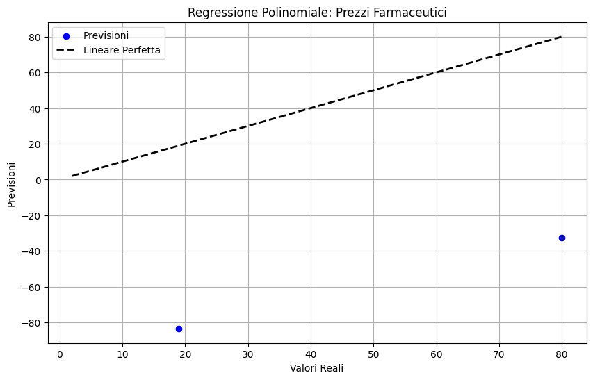

```python
# Importare le librerie necessarie
import numpy as np
import pandas as pd
import matplotlib.pyplot as plt
from sklearn.model_selection import train_test_split
from sklearn.linear_model import LinearRegression
from sklearn.preprocessing import PolynomialFeatures, StandardScaler
from sklearn.metrics import mean_squared_error, r2_score
from sklearn.pipeline import make_pipeline

# Creare un dataset simulato
data = {
    'Dosaggio (mg)': [11, 44, 15, 30, 50, 60, 70, 80, 90, 100],
    'Concorrenza (n° competitors)': [5, 10, 8, 6, 4, 9, 7, 3, 2, 1],
    'Tipo di Farmaco (1 per generico, 0 per brand)': [0, 1, 0, 1, 0, 1, 0, 1, 0, 1],
    'Prezzo ($)': [2, 80, 3, 6, 3, 9, 6, 50, 19, 14]
}

df = pd.DataFrame(data)

# Controllare se ci sono valori mancanti
if df.isnull().values.any():
    raise ValueError("Il dataset contiene valori mancanti.")

# Separare le feature dalla variabile target
X = df[['Dosaggio (mg)', 'Concorrenza (n° competitors)', 'Tipo di Farmaco (1 per generico, 0 per brand)']]
y = df['Prezzo ($)']

# Dividere il dataset in training e test set
X_train, X_test, y_train, y_test = train_test_split(X, y, test_size=0.2, random_state=42)

# Creare un modello di regressione polinomiale con normalizzazione
degree = 2  # Grado polinomiale (puoi modificarlo per testare gradi diversi)
if degree < 1:
    raise ValueError("Il grado polinomiale deve essere almeno 1.")

poly_model = make_pipeline(StandardScaler(), PolynomialFeatures(degree=degree), LinearRegression())
poly_model.fit(X_train, y_train)

# Fare previsioni sul test set
y_poly_pred = poly_model.predict(X_test)

# Valutare il modello
mse_poly = mean_squared_error(y_test, y_poly_pred)
r2_poly = r2_score(y_test, y_poly_pred)

# Stampa i risultati
print(f'MSE Polinomiale: {mse_poly:.2f}')
print(f'R² Polinomiale: {r2_poly:.2f}')

# Coefficienti del modello
linear_model = poly_model.named_steps['linearregression']
features = poly_model.named_steps['polynomialfeatures'].get_feature_names_out(X.columns)
coefficients = pd.DataFrame(linear_model.coef_, index=features, columns=["Coefficient"])
print("\nCoefficienti del modello:\n", coefficients)

# Visualizzare i risultati
plt.figure(figsize=(10, 6))
plt.scatter(y_test, y_poly_pred, color='blue', label='Previsioni')
plt.plot([y.min(), y.max()], [y.min(), y.max()], 'k--', lw=2, label='Lineare Perfetta')
plt.xlabel('Valori Reali')
plt.ylabel('Previsioni')
plt.title('Regressione Polinomiale: Prezzi Farmaceutici')
plt.legend()
plt.grid(True)
plt.show()
```